# Solar Flare Analysis and Rule Mining

Ada Lazuli

2022-06-07

# Data Loading

```r
df <- read.csv("solar_flare.csv")
```

The solar flare data has 323 observations and 13 variables for each observation. More specifically, the variables are:

```r
names(df)
```

```
##  [1] "c.class"               "m.class"               "x.class"
##  [4] "mod_zurich_class"      "largest_spot_size"     "spot_distribution"
##  [7] "activity"              "evolution"             "previous_day_activity"
## [10] "hist_complex"          "become_hist_complex"   "area"
## [13] "area_largest"
```

Lastly, there are exactly 0 missing values in this data set.

## Data Preparation

The structure of the data is:

```r
str(df)
```

```
## 'data.frame':    323 obs. of  13 variables:
##  $ c.class              : int  0 0 0 0 0 0 0 0 0 0 ...
##  $ m.class              : int  0 0 0 0 0 0 0 0 0 0 ...
##  $ x.class              : int  0 0 0 0 0 0 0 0 0 0 ...
##  $ mod_zurich_class     : chr  "C" "D" "C" "D" ...
##  $ largest_spot_size    : chr  "S" "S" "S" "S" ...
##  $ spot_distribution    : chr  "O" "O" "O" "O" ...
##  $ activity             : int  1 1 1 1 1 1 1 1 1 1 ...
##  $ evolution            : int  2 3 3 3 3 2 2 2 3 3 ...
##  $ previous_day_activity: int  1 1 1 1 1 1 1 1 1 1 ...
##  $ hist_complex         : int  1 1 1 1 1 1 1 1 1 1 ...
##  $ become_hist_complex  : int  2 2 2 2 2 2 2 2 2 2 ...
##  $ area                 : int  1 1 1 1 1 1 1 1 1 1 ...
##  $ area_largest         : int  2 2 1 2 2 2 1 2 2 1 ...
```

According to Bradshaw (1989), the several of these values are factors, but R seems to have missed this as the data was read into memory.

```r
factors <- c( "mod_zurich_class","largest_spot_size","spot_distribution","activity","evolution","previous_day_activity","hist_complex","become_hist_complex","area","area_largest" )
for (f in factors) {
  df[[f]] <- factor(df[[f]])
}
str(df)
```

```
## 'data.frame':    323 obs. of  13 variables:
##  $ c.class              : int  0 0 0 0 0 0 0 0 0 0 ...
##  $ m.class              : int  0 0 0 0 0 0 0 0 0 0 ...
##  $ x.class              : int  0 0 0 0 0 0 0 0 0 0 ...
##  $ mod_zurich_class     : Factor w/ 6 levels "B","C","D","E",..: 2 3 2 3 3 3 3 3 3 2 ...
##  $ largest_spot_size    : Factor w/ 6 levels "A","H","K","R",..: 5 5 5 5 1 1 1 1 3 4 ...
##  $ spot_distribution    : Factor w/ 4 levels "C","I","O","X": 3 3 3 3 3 3 3 3 3 3 ...
##  $ activity             : Factor w/ 2 levels "1","2": 1 1 1 1 1 1 1 1 1 1 ...
##  $ evolution            : Factor w/ 3 levels "1","2","3": 2 3 3 3 3 2 2 2 3 3 ...
##  $ previous_day_activity: Factor w/ 2 levels "1","3": 1 1 1 1 1 1 1 1 1 1 ...
##  $ hist_complex         : Factor w/ 2 levels "1","2": 1 1 1 1 1 1 1 1 1 1 ...
##  $ become_hist_complex  : Factor w/ 2 levels "1","2": 2 2 2 2 2 2 2 2 2 2 ...
##  $ area                 : Factor w/ 2 levels "1","2": 1 1 1 1 1 1 1 1 1 1 ...
##  $ area_largest         : Factor w/ 2 levels "1","2": 2 2 1 2 2 2 1 2 2 1 ...
```

# Exploratory Analysis

## Univariate Analysis

### c.class

According to Bradshaw (1989), `c.class` is a count of the number of *common* flares in the region during a 24 hour period. This variable is loaded in R as a integer

The 5-number summary for c.class is and distribution is:

```r
summary(df$c.class)
```

```
##    Min. 1st Qu.  Median    Mean 3rd Qu.    Max.
##  0.0000  0.0000  0.0000  0.1331  0.0000  2.0000
```

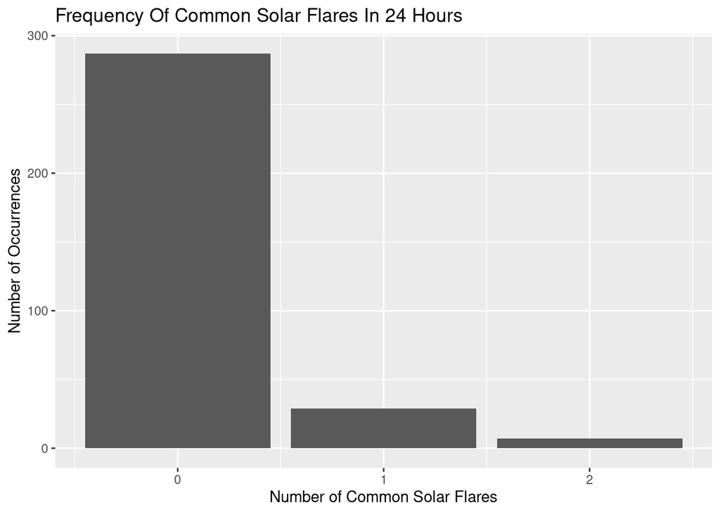

```r
ggplot(df, aes(x = c.class)) + geom_bar() + ggtitle("Frequency Of Common Solar Flares In 24 Hours") +  xlab("Number of Common Solar Flares") + ylab("Number of Occurrences")
```

### m.class

The 5-number summary for c.class is and distribution is:

```r
summary(df$m.class)
```

```
##    Min. 1st Qu.  Median    Mean 3rd Qu.    Max.
##  0.0000  0.0000  0.0000  0.1362  0.0000  4.0000
```

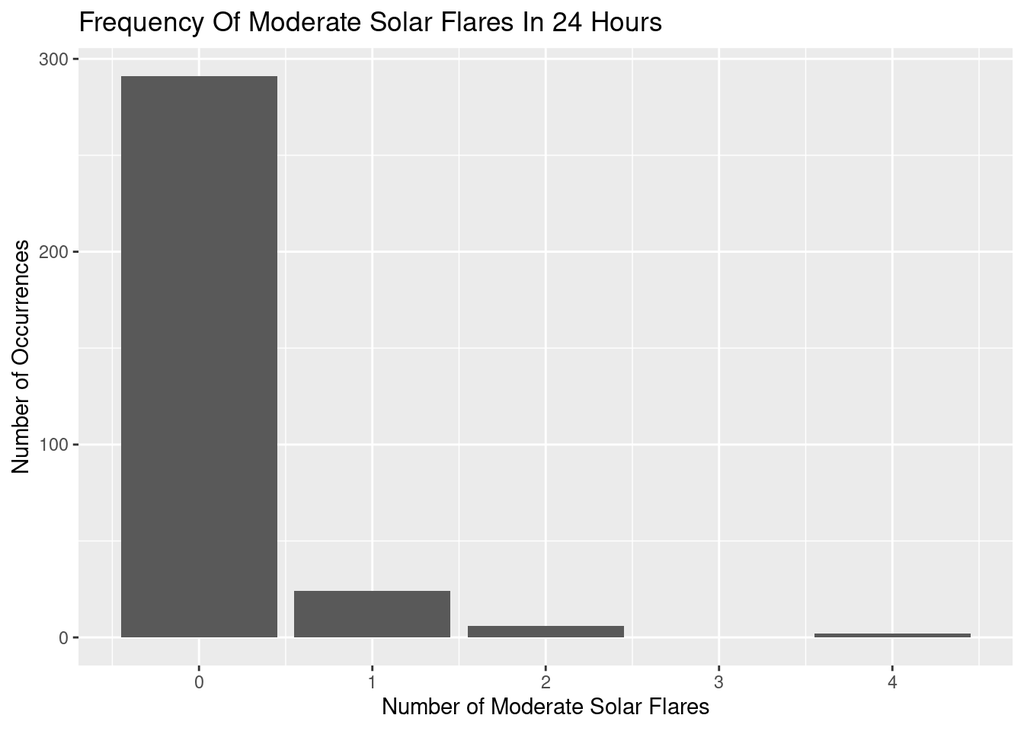

```r
ggplot(df, aes(x = m.class)) + geom_bar() + ggtitle("Frequency Of Moderate Solar Flares In 24 Hours") +  xlab("Number of Moderate Solar Flares") + ylab("Number of Occurrences")
```

It seems that m.class has a strong right skew and the majority of the observations have 0 occurrences of *moderate* solar flares in a 24 hour period.

Additionally, there seems to be an oddity with the moderate class variable in that there are 0 occurrences of 3 moderate events, but a total of 2 occurrences of 4 moderate events in a 24 hour period.

These 2 occurrences of 4 moderate solar flares in a 24 hour period seem outlines.

### x.class

According to Bradshaw (1989), `x.class` is a count of the number of *severe* flares in the region during a 24 hour period. This variable is loaded in R as a integer

The 5-number summary for c.class is and distribution is:

```r
summary(df$x.class)
```

```
##    Min. 1st Qu.  Median    Mean 3rd Qu.    Max.
## 0.00000 0.00000 0.00000 0.02167 0.00000 1.00000
```

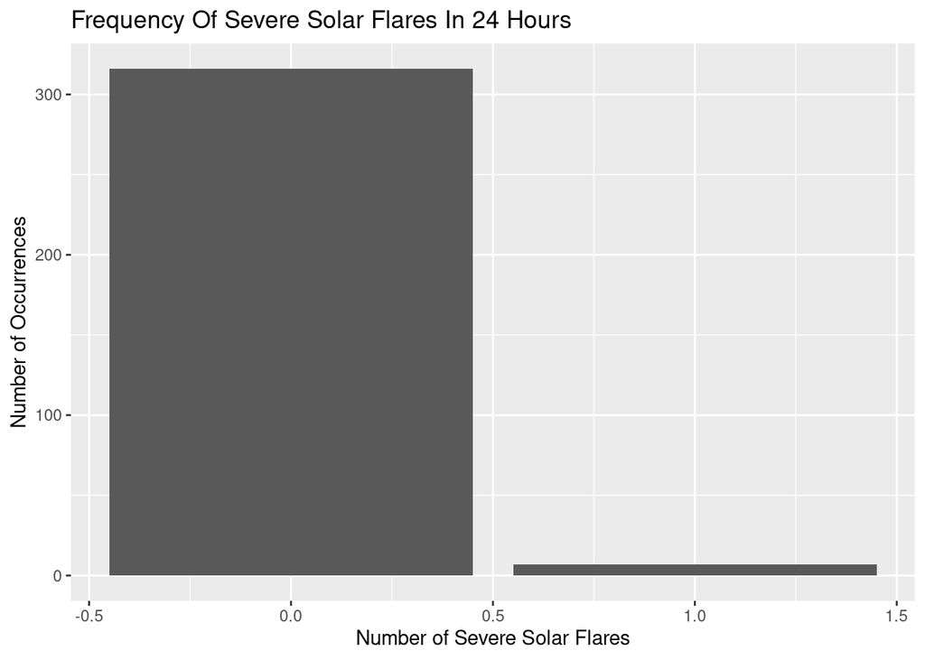

```r
ggplot(df, aes(x = x.class)) + geom_bar() + ggtitle("Frequency Of Severe Solar Flares In 24 Hours") +  xlab("Number of Severe Solar Flares") + ylab("Number of Occurrences")
```

### mod_zurich_class

According to the SIDC, the modified zurich classification refers to the characteristics of the penumbra. This variable is stored as a factor in R. The classifications seen in the data are B, C, D, E, F, H.

**Notably, A class observations are missing.**

The distribution of the modified zurich classes found in the data is depicted below.

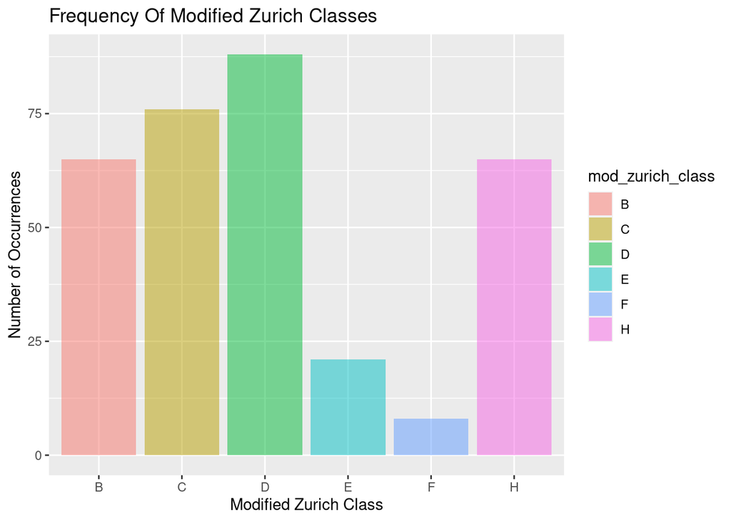

```r
ggplot(df, aes(x = mod_zurich_class, fill = mod_zurich_class)) + geom_bar(alpha = 0.5) + ggtitle("Frequency Of Modified Zurich Classes") +  xlab("Modified Zurich Class") + ylab("Number of Occurrences")
```

### largest_spot_size (P Classes)

According to the SIDC, the P Classes (listed as `largest_spot_size` in the data) describes characteristics of the primary penumbra. This variable is stored as a factor in R. The classifications seen in the data are A, H, K, R, S, X.

The distribution of the P classes found in the data is depicted below.

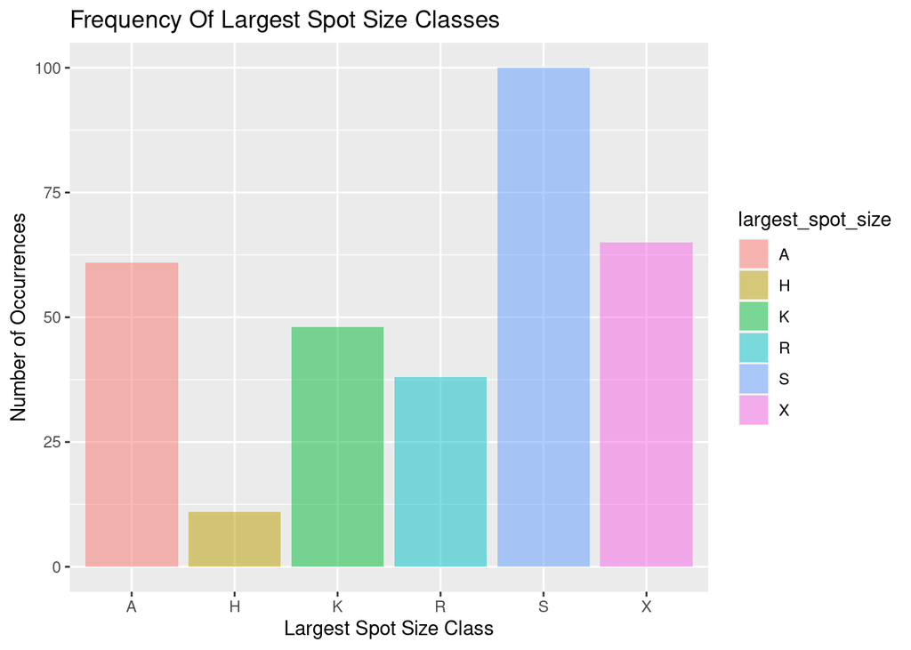

```r
ggplot(df, aes(x = largest_spot_size, fill = largest_spot_size)) + geom_bar(alpha = 0.5) + ggtitle("Frequency Of Largest Spot Size Classes") +  xlab("Largest Spot Size Class") + ylab("Number of Occurrences")
```

The distribution in the dataset is not uniform. It appears that **H** class is under represented while **S** class is over represented.

### Spot Distribution (C Classes)

According to the SIDC, the C Classes (listed as `spot_distribution` in the data) describes characteristics of the primary penumbra. This variable is stored as a factor in R. The classifications seen in the data are C, I, O, X.

The distribution of the C classes found in the data is depicted below.

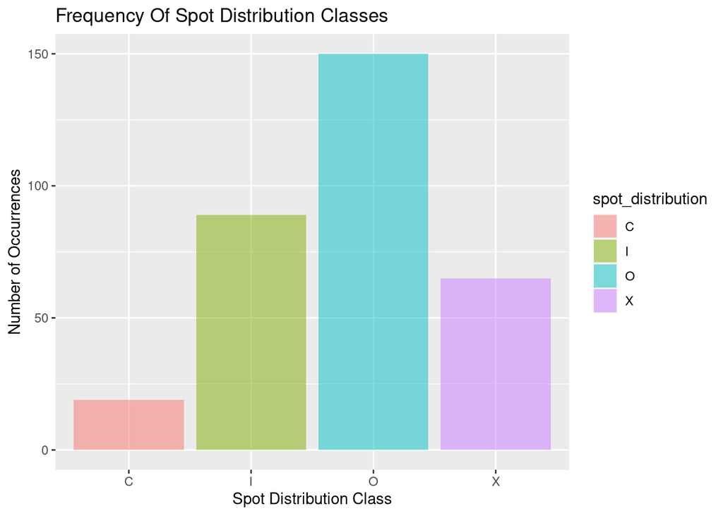

```r
ggplot(df, aes(x = spot_distribution, fill = spot_distribution)) + geom_bar(alpha = 0.5) + ggtitle("Frequency Of Spot Distribution Classes") +  xlab("Spot Distribution Class") + ylab("Number of Occurrences")
```

It appears that the c-class is not uniformly distributed among the observations, with **C** being much less frequent than the other classes and **O** being much more frequent than the other classes.

### Activity

The `activity` variable, according to Bradshaw (1989), details whether or not the activity has not changed over that last 24 hours or has been observed to be reduced.

This variable is stored in R as a factor. A 1 indicates reduced activity while a 2 indicated no change.

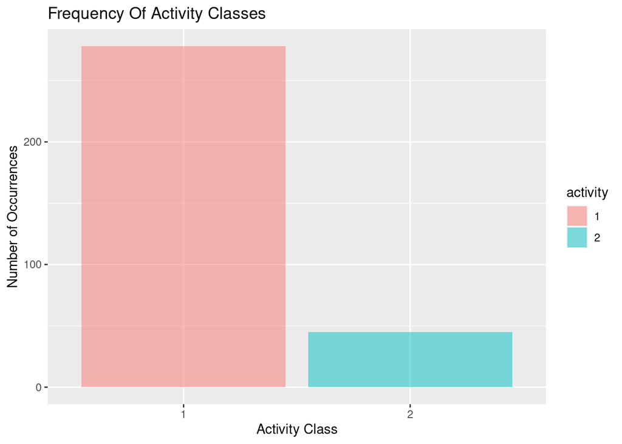

```r
ggplot(df, aes(x = activity, fill = activity)) + geom_bar(alpha = 0.5) +  ggtitle("Frequency Of Activity Classes") +  xlab("Activity Class") + ylab("Number of Occurrences")
```

It seems that the majority of the observations have reduced activity over a 24 hour period, with 13.9318885% showing unchanged activity in a 24 hour period.

### Evolution

The `evolution` variable, according to Bradshaw (1989), details changes in size over the last 24 hours. The variable is categorical, represented by numbers with the following meanings: 1. Decay 2. No Growth 3. Growth

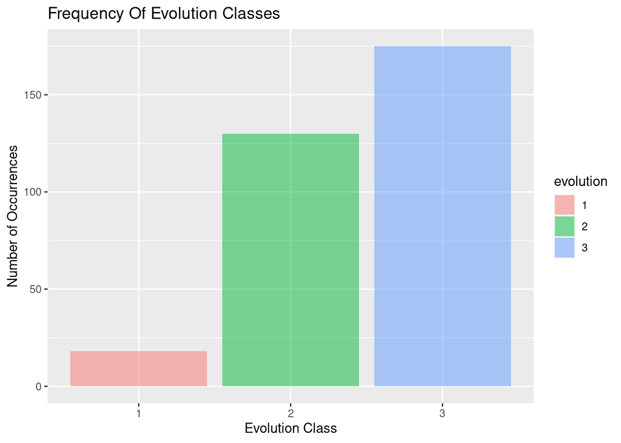

```r
ggplot(df, aes(x = evolution, fill = evolution)) + geom_bar(alpha = 0.5) +ggtitle("Frequency Of Evolution Classes") +  xlab("Evolution Class") + ylab("Number of Occurrences")
```

The distribution of the evolution classes is non uniform. It appears that it is uncommon for decay and more common for growth.

### Previous Day Activity

The `previous_day_activity` variable, according to Bradshaw (1989), details the flare activity of the last previous 24 hours, with the following codes:

1. Nothing as big as an M1
2. One M1
3. More than one M1

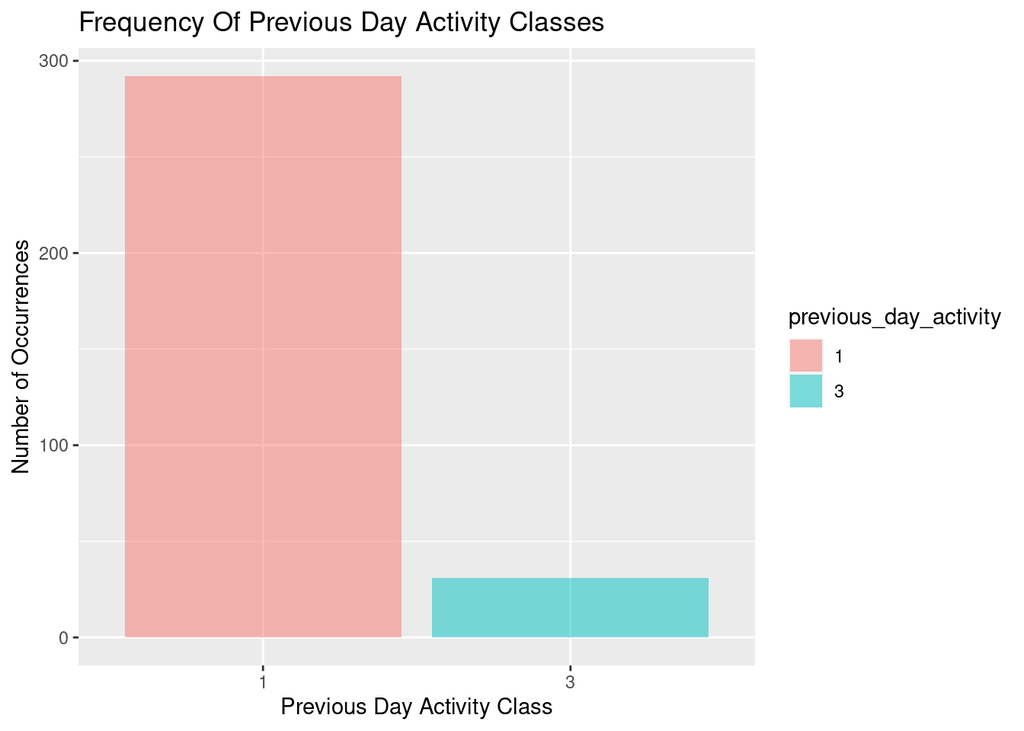

```r
ggplot(df, aes(x = previous_day_activity, fill = previous_day_activity)) + geom_bar(alpha = 0.5) + ggtitle("Frequency Of Previous Day Activity Classes") +  xlab("Previous Day Activity Class") + ylab("Number of Occurrences")
```

It would appear that the majority of the observations had nothing as large as an M1 occur on the previous. However, 9.5975232% of the observations had more than one M1 event occur.

### Historically Complex

The `hist_complex` variable, according to Bradshaw (1989), details whether the region has historically been complex.

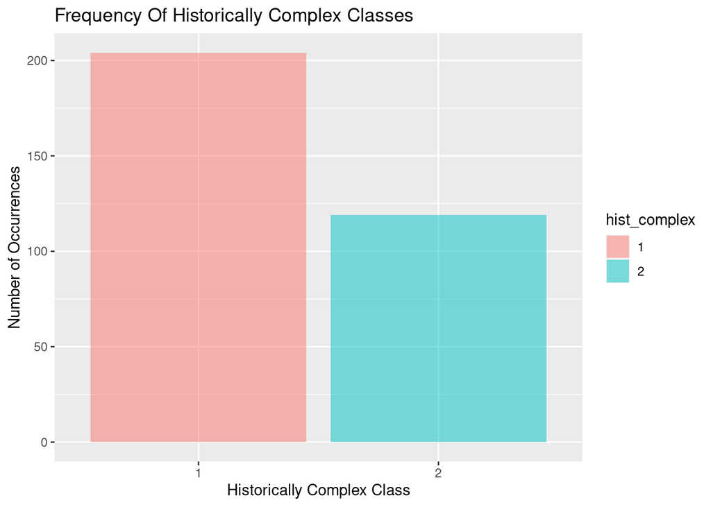

```r
ggplot(df, aes(x = hist_complex, fill = hist_complex)) + geom_bar(alpha = 0.5) +  ggtitle("Frequency Of Historically Complex Classes") +  xlab("Historically Complex Class") + ylab("Number of Occurrences")
```

It seems that the majority of the observations are historically complex, with 36.8421053% of the observations not being historically complex

### Became Historically Complex

The `become_hist_complex` variable, according to Bradshaw (1989), details whether the region became historically complex during this pass across the sun’s disk.

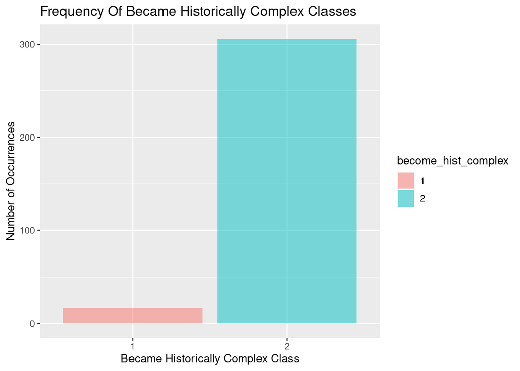

```r
ggplot(df, aes(x = become_hist_complex, fill = become_hist_complex)) + geom_bar(alpha = 0.5) + ggtitle("Frequency Of Became Historically Complex Classes") +  xlab("Became Historically Complex Class") + ylab("Number of Occurrences")
```

### Area

The `area` variable, according to Bradshaw (1989) is a categorical indication of whether or not the region in the observation is large or small.

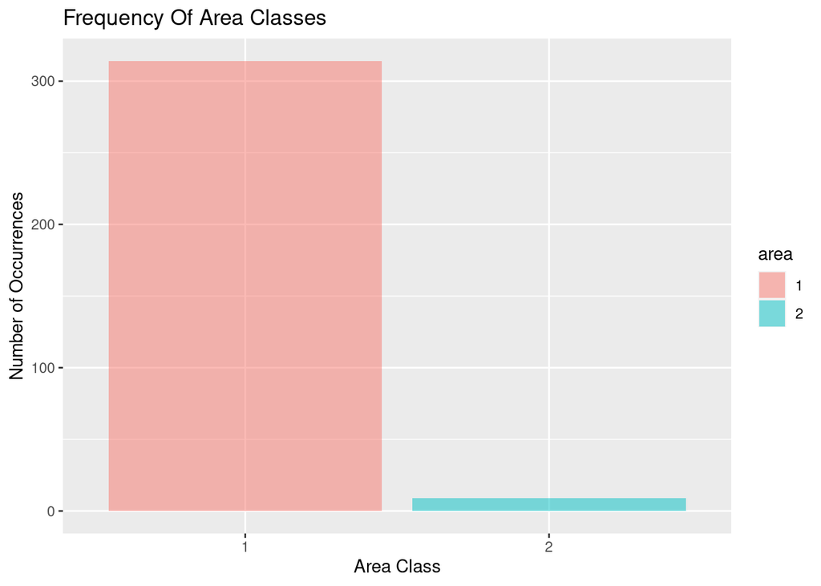

```r
ggplot(df, aes(x = area, fill = area)) + geom_bar(alpha = 0.5) +  ggtitle("Frequency Of Area Classes") +  xlab("Area Class") + ylab("Number of Occurrences")
```

The `area_largest` variable, according to Bradshaw (1989) is a categorical indication of whether or not the largest spot of the region is greater than or less than 5.

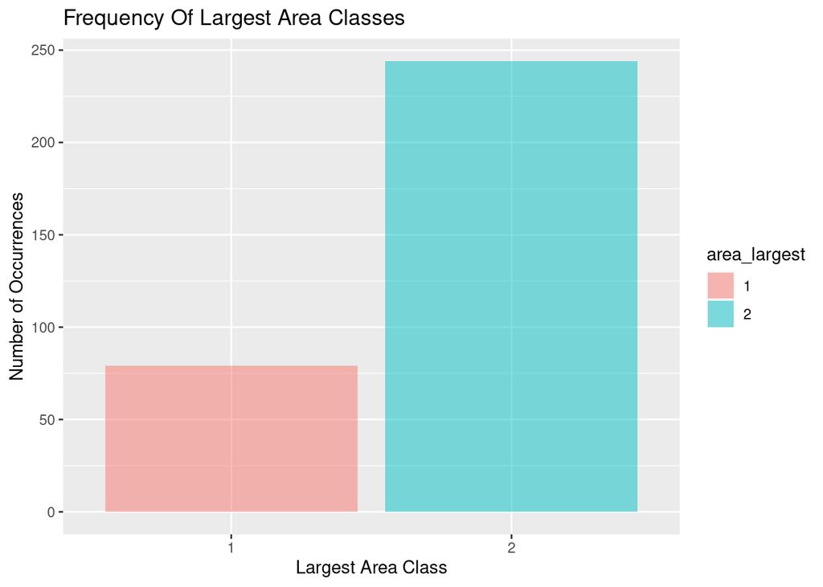

```r
ggplot(df, aes(x = area_largest, fill = area_largest)) + geom_bar(alpha = 0.5) +  ggtitle("Frequency Of Largest Area Classes") +  xlab("Largest Area Class") + ylab("Number of Occurrences")
```

It seems that the majority of the largest spots of a solar flare are greater than 5.

# Rule Generation

This section generates rules using the arules and arulesViz packages. First, prepare the numeric variables and load the libraries

```r
library(arules)
library(arulesViz)
factors <- c("c.class", "m.class","x.class")
for (f in factors) {
  df[[f]] <- factor(df[[f]])
}
```

## Growth Rules (Evolution = 3)

When the evolution variable is 3, then the region was experiencing growth. This could indicate that region would be more likely to have flare events in the future.

```r
rules <- apriori(df, parameter = list(supp=0.1, conf=0.8, minlen=2), appearance=list(rhs=c("evolution=3")))
```

```
## Apriori
##
## Parameter specification:
##  confidence minval smax arem  aval originalSupport maxtime support minlen
##         0.8    0.1    1 none FALSE            TRUE       5     0.1      2
##  maxlen target  ext
##      10  rules TRUE
##
## Algorithmic control:
##  filter tree heap memopt load sort verbose
##     0.1 TRUE TRUE  FALSE TRUE    2    TRUE
##
## Absolute minimum support count: 32
##
## set item appearances ...[1 item(s)] done [0.00s].
## set transactions ...[40 item(s), 323 transaction(s)] done [0.00s].
## sorting and recoding items ... [26 item(s)] done [0.00s].
## creating transaction tree ... done [0.00s].
## checking subsets of size 1 2 3 4 5 6 7 8 9 10 done [0.01s].
## writing ... [32 rule(s)] done [0.00s].
## creating S4 object  ... done [0.00s].
```

```r
rules.sorted <- sort(rules, by="lift")
subset.matrix <- is.subset(rules.sorted, rules.sorted)
subset.matrix[lower.tri(subset.matrix, diag=T)] <- F
redundant <- colSums(subset.matrix, na.rm=T) >= 1
rules.pruned <- rules.sorted[!redundant]
inspect(sort(rules.pruned, by="lift"))
```

```
##     lhs                           rhs             support confidence  coverage     lift count
## [1] {spot_distribution=I,
##      previous_day_activity=1,
##      hist_complex=1}           => {evolution=3} 0.1021672  0.8461538 0.1207430 1.561758    33
## [2] {c.class=0,
##      spot_distribution=I,
##      hist_complex=1}           => {evolution=3} 0.1052632  0.8292683 0.1269350 1.530592    34
## [3] {m.class=0,
##      spot_distribution=I,
##      hist_complex=1}           => {evolution=3} 0.1021672  0.8250000 0.1238390 1.522714    33
## [4] {spot_distribution=I,
##      hist_complex=1}           => {evolution=3} 0.1083591  0.8139535 0.1331269 1.502326    35
```

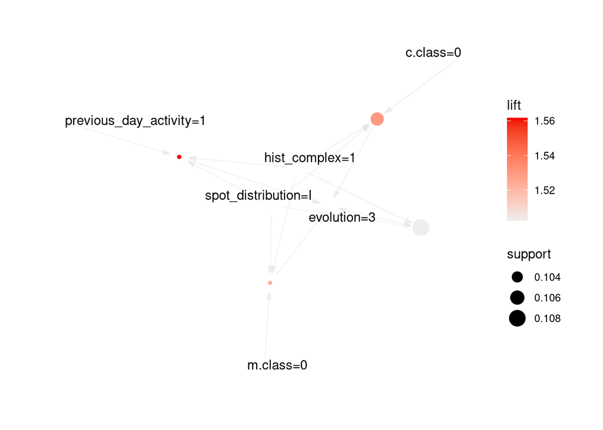

```r
plot(rules.pruned, method="graph")
```

It seems like a spot distribution of I and a history of complexity are indicators of growth in the region.

## Decay Rules (Evolution = 1)

When evolution = 1, the region is experiencing decay. This could potentially be useful for finding regions to ignore.

```r
rules <- apriori(df, parameter = list(supp=0.1, conf=0.7, minlen=2), appearance=list(rhs=c("evolution=1")))
```

```
## Apriori
##
## Parameter specification:
##  confidence minval smax arem  aval originalSupport maxtime support minlen
##         0.7    0.1    1 none FALSE            TRUE       5     0.1      2
##  maxlen target  ext
##      10  rules TRUE
##
## Algorithmic control:
##  filter tree heap memopt load sort verbose
##     0.1 TRUE TRUE  FALSE TRUE    2    TRUE
##
## Absolute minimum support count: 32
##
## set item appearances ...[1 item(s)] done [0.00s].
## set transactions ...[40 item(s), 323 transaction(s)] done [0.00s].
## sorting and recoding items ... [26 item(s)] done [0.00s].
## creating transaction tree ... done [0.00s].
## checking subsets of size 1 2 3 4 5 6 7 8 9 10 done [0.01s].
## writing ... [0 rule(s)] done [0.00s].
## creating S4 object  ... done [0.00s].
```

```r
rules
```

```
## set of 0 rules
```

However it seems that rules could not be found for decay. This might be from only 5.5727554% of the observations having decay.

## Reduced Activity (Activity = 1)

Reduced activity could be an indicator that a region is less likely to have a solar flare event and could be useful in prioritizing regions for monitoring.

```r
rules <- apriori(df, parameter = list(supp=0.1, conf=0.7, minlen=2), appearance=list(rhs=c("activity=1")))
```

```
## Apriori
##
## Parameter specification:
##  confidence minval smax arem  aval originalSupport maxtime support minlen
##         0.7    0.1    1 none FALSE            TRUE       5     0.1      2
##  maxlen target  ext
##      10  rules TRUE
##
## Algorithmic control:
##  filter tree heap memopt load sort verbose
##     0.1 TRUE TRUE  FALSE TRUE    2    TRUE
##
## Absolute minimum support count: 32
##
## set item appearances ...[1 item(s)] done [0.00s].
## set transactions ...[40 item(s), 323 transaction(s)] done [0.00s].
## sorting and recoding items ... [26 item(s)] done [0.00s].
## creating transaction tree ... done [0.00s].
## checking subsets of size 1 2 3 4 5 6 7 8 9 10 done [0.01s].
## writing ... [6326 rule(s)] done [0.00s].
## creating S4 object  ... done [0.00s].
```

```r
rules.sorted <- sort(rules, by="lift")
subset.matrix <- is.subset(rules.sorted, rules.sorted)
subset.matrix[lower.tri(subset.matrix, diag=T)] <- F
redundant <- colSums(subset.matrix, na.rm=T) >= 1
rules.pruned <- rules.sorted[!redundant]
inspect(sort(rules.pruned[0:5], by="lift"))
```

```
##     lhs                           rhs            support confidence  coverage     lift count
## [1] {c.class=0,
##      m.class=0,
##      mod_zurich_class=B,
##      evolution=3}              => {activity=1} 0.1207430          1 0.1207430 1.161871    39
## [2] {c.class=0,
##      m.class=0,
##      largest_spot_size=X,
##      evolution=3}              => {activity=1} 0.1207430          1 0.1207430 1.161871    39
## [3] {m.class=0,
##      evolution=3,
##      hist_complex=1,
##      area_largest=1}           => {activity=1} 0.1331269          1 0.1331269 1.161871    43
## [4] {evolution=3,
##      previous_day_activity=1,
##      hist_complex=1,
##      area_largest=1}           => {activity=1} 0.1331269          1 0.1331269 1.161871    43
## [5] {c.class=0,
##      mod_zurich_class=D,
##      previous_day_activity=1,
##      hist_complex=1}           => {activity=1} 0.1083591          1 0.1083591 1.161871    35
```

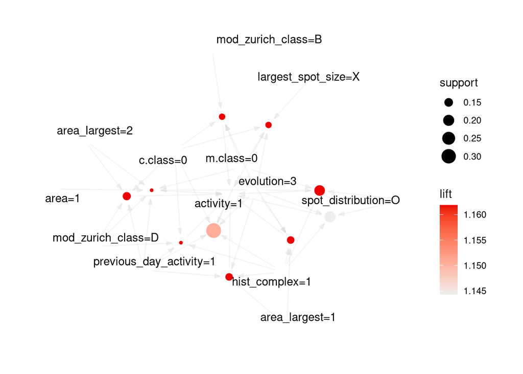

```r
plot(rules.pruned[0:10], method="graph")
```

The algorithm seems to have been able to find several different rules reduced activity in a region. The algorithm seems to have found several possible candidates. This could be from 86.0681115% of the observations having reduced activity, however.

## Historically Complex (hist_complex = 1)

Finding rules for regions that have historically been classified as complex could useful for finding such regions quickly.

```r
rules <- apriori(df, parameter = list(supp=0.1, conf=0.7, minlen=2), appearance=list(rhs=c("hist_complex=1")))
```

```
## Apriori
##
## Parameter specification:
##  confidence minval smax arem  aval originalSupport maxtime support minlen
##         0.7    0.1    1 none FALSE            TRUE       5     0.1      2
##  maxlen target  ext
##      10  rules TRUE
##
## Algorithmic control:
##  filter tree heap memopt load sort verbose
##     0.1 TRUE TRUE  FALSE TRUE    2    TRUE
##
## Absolute minimum support count: 32
##
## set item appearances ...[1 item(s)] done [0.00s].
## set transactions ...[40 item(s), 323 transaction(s)] done [0.00s].
## sorting and recoding items ... [26 item(s)] done [0.00s].
## creating transaction tree ... done [0.00s].
## checking subsets of size 1 2 3 4 5 6 7 8 9 10 done [0.01s].
## writing ... [3223 rule(s)] done [0.00s].
## creating S4 object  ... done [0.00s].
```

```r
rules.sorted <- sort(rules, by="lift")
subset.matrix <- is.subset(rules.sorted, rules.sorted)
subset.matrix[lower.tri(subset.matrix, diag=T)] <- F
redundant <- colSums(subset.matrix, na.rm=T) >= 1
rules.pruned <- rules.sorted[!redundant]
inspect(sort(rules.pruned[0:5], by="lift"))
```

```
##     lhs                          rhs                support confidence  coverage     lift count
## [1] {mod_zurich_class=B,
##      area_largest=1}          => {hist_complex=1} 0.1486068          1 0.1486068 1.583333    48
## [2] {mod_zurich_class=B,
##      evolution=3}             => {hist_complex=1} 0.1393189          1 0.1393189 1.583333    45
## [3] {largest_spot_size=X,
##      area_largest=1}          => {hist_complex=1} 0.1486068          1 0.1486068 1.583333    48
## [4] {largest_spot_size=X,
##      evolution=3}             => {hist_complex=1} 0.1393189          1 0.1393189 1.583333    45
## [5] {mod_zurich_class=B,
##      spot_distribution=O,
##      previous_day_activity=1} => {hist_complex=1} 0.1578947          1 0.1578947 1.583333    51
```

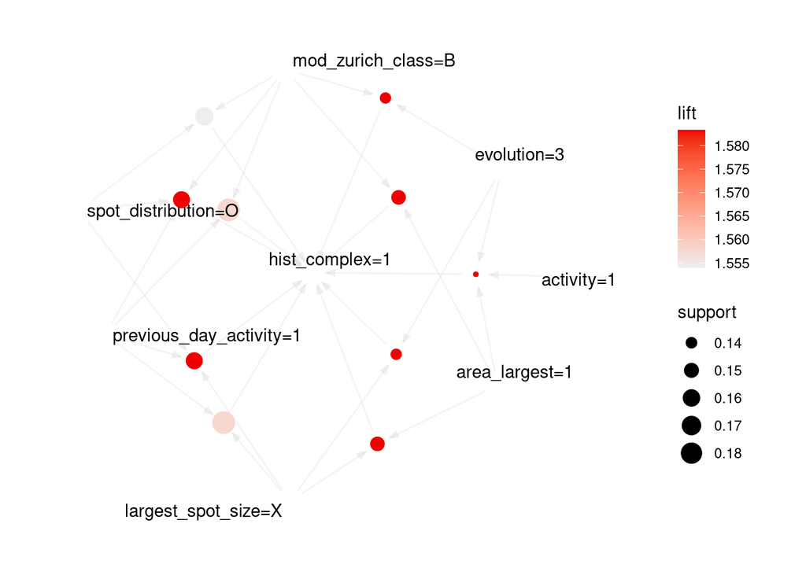

```r
plot(rules.pruned[0:10], method="graph")
```

It seems that the region having a Modified Zurich Class of B or having a largest spot size of X are factors in whether a region is complex.

## Not Historically Complex (hist_complex=2)

On the converse, finding rules for regions that have historically not been complex could be useful for determining if regions pose less of a threat and need less monitoring.

```r
rules <- apriori(df, parameter = list(supp=0.1, conf=0.7, minlen=2), appearance=list(rhs=c("hist_complex=2")))
```

```
## Apriori
##
## Parameter specification:
##  confidence minval smax arem  aval originalSupport maxtime support minlen
##         0.7    0.1    1 none FALSE            TRUE       5     0.1      2
##  maxlen target  ext
##      10  rules TRUE
##
## Algorithmic control:
##  filter tree heap memopt load sort verbose
##     0.1 TRUE TRUE  FALSE TRUE    2    TRUE
##
## Absolute minimum support count: 32
##
## set item appearances ...[1 item(s)] done [0.00s].
## set transactions ...[40 item(s), 323 transaction(s)] done [0.00s].
## sorting and recoding items ... [26 item(s)] done [0.00s].
## creating transaction tree ... done [0.00s].
## checking subsets of size 1 2 3 4 5 6 7 8 9 10 done [0.01s].
## writing ... [8 rule(s)] done [0.00s].
## creating S4 object  ... done [0.00s].
```

```r
rules.sorted <- sort(rules, by="lift")
subset.matrix <- is.subset(rules.sorted, rules.sorted)
subset.matrix[lower.tri(subset.matrix, diag=T)] <- F
redundant <- colSums(subset.matrix, na.rm=T) >= 1
rules.pruned <- rules.sorted[!redundant]
inspect(sort(rules.pruned, by="lift"))
```

```
##     lhs                       rhs               support confidence  coverage     lift count
## [1] {largest_spot_size=K,
##      area_largest=2}       => {hist_complex=2} 0.120743  0.8297872 0.1455108 2.252280    39
## [2] {largest_spot_size=K}  => {hist_complex=2} 0.120743  0.8125000 0.1486068 2.205357    39
```

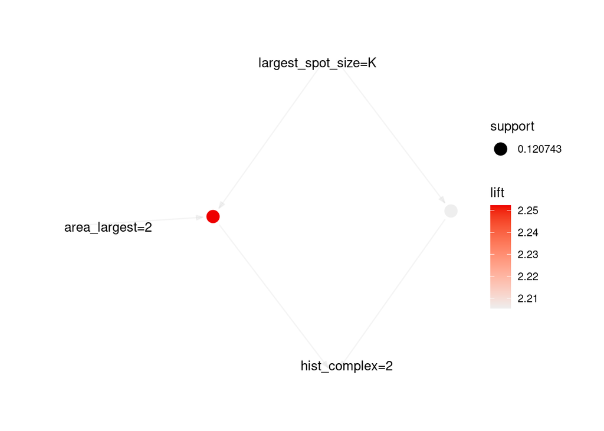

```r
plot(rules.pruned, method="graph")
```

It seems that a region having a largest spot size of K tends to a region not being complex. This rule was also the highest lift seen during analysis.

# References

Bradshaw, G. (1989). UCI Machine Learning Repository: Solar Flare Data Set [CSV]. Retrieved June 8, 2022, from https://archive.ics.uci.edu/ml/datasets/solar+flare

SIDC. (n.d.). Codes, terminology and classifications. User guide from SIDC - Royal Observatory of Belgium. Retrieved June 8, 2022, from https://www.sidc.be/educational/classification.php